# Notebook 07 — R EDA with ggplot2

Muhammad Umar Shahid

2026-04-20

## Install & Load Libraries

| Package | Purpose |
| --- | --- |
| `S7` | Object-oriented system required by ggplot2 4.0+ — must install as binary on Windows |
| `tidyverse` | Core suite combining ggplot2, dplyr, readr, tidyr, purrr — equivalent to pandas + matplotlib + seaborn in Python |
| `scales` | Formats chart axes as $1,000 or 10% — used in every ggplot2 chart |
| `lubridate` | Parses and handles date columns like Order Date cleanly |
| `ggthemes` | Extra professional themes for ggplot2 charts |

```r
options(timeout = 300)
options(repos = c(CRAN = "https://cloud.r-project.org"))

packages <- c("S7", "tidyverse", "scales", "lubridate", "ggthemes")

for (pkg in packages) {
  if (!requireNamespace(pkg, quietly = TRUE)) {
    cat("📦 Installing:", pkg, "\n")
    install.packages(pkg, type = "binary")
  } else {
    cat("✅ Already installed:", pkg, "\n")
  }
}
```

```
📦 Installing: S7

  There is a binary version available (and will be installed) but the source version is later:
   binary  source
S7  0.2.1 0.2.1-1
```

```
✅ Already installed: tidyverse
✅ Already installed: scales
✅ Already installed: lubridate
✅ Already installed: ggthemes
```

```r
library(tidyverse)
library(scales)
library(lubridate)
library(ggthemes)

cat("\n✅ All libraries loaded successfully\n")
```

```
✅ All libraries loaded successfully
```

## Load Dataset

`read_csv()` is R’s equivalent of `pd.read_csv()`. `glimpse()` is R’s equivalent of `df.info()` — shows column types and first few values of every column at a glance.

```r
df <- read_csv("../data/processed/superstore_clean.csv")

cat("Rows   :", nrow(df), "\n")
```

```
Rows   : 8286
```

```r
cat("Columns:", ncol(df), "\n")
```

```
Columns: 35
```

```r
glimpse(df)
```

```
Rows: 8,286
Columns: 35
$ `Row ID`           <dbl> 1, 2, 13, 14, 15, 16, 17, 18, 22, 23, 24, 25, 26, 27, 28, 29, 30, 31, 32, 33, 34, 35, 36, 37, 38, 39, 40, 41, 43, 44, 47, …
$ `Order ID`         <chr> "CA-2016-152156", "CA-2016-152156", "CA-2017-114412", "CA-2016-161389", "US-2015-118983", "US-2015-118983", "CA-2014-10589…
$ `Order Date`       <date> 2016-08-11, 2016-08-11, 2017-04-15, 2016-05-12, 2015-11-22, 2015-11-22, 2014-11-11, 2014-05-13, 2016-09-12, 2016-09-12, 2…
$ `Ship Date`        <date> 2016-11-11, 2016-11-11, 2017-04-20, 2016-10-12, 2015-11-26, 2015-11-26, 2014-11-18, 2014-05-15, 2016-12-13, 2016-12-13, 2…
$ `Ship Mode`        <chr> "Second Class", "Second Class", "Standard Class", "Standard Class", "Standard Class", "Standard Class", "Standard Class", …
$ `Customer ID`      <chr> "CG-12520", "CG-12520", "AA-10480", "IM-15070", "HP-14815", "HP-14815", "PK-19075", "AG-10270", "KB-16585", "KB-16585", "S…
$ `Customer Name`    <chr> "Claire Gute", "Claire Gute", "Andrew Allen", "Irene Maddox", "Harold Pawlan", "Harold Pawlan", "Pete Kriz", "Alejandro Gr…
$ Segment            <chr> "Consumer", "Consumer", "Consumer", "Consumer", "Home Office", "Home Office", "Consumer", "Consumer", "Corporate", "Corpor…
$ Country            <chr> "United States", "United States", "United States", "United States", "United States", "United States", "United States", "Un…
$ City               <chr> "Henderson", "Henderson", "Concord", "Seattle", "Fort Worth", "Fort Worth", "Madison", "West Jordan", "Fremont", "Fremont"…
$ State              <chr> "Kentucky", "Kentucky", "North Carolina", "Washington", "Texas", "Texas", "Wisconsin", "Utah", "Nebraska", "Nebraska", "Pe…
$ `Postal Code`      <dbl> 42420, 42420, 28027, 98103, 76106, 76106, 53711, 84084, 68025, 68025, 19140, 84057, 90049, 90049, 19140, 19140, 19140, 191…
$ Region             <chr> "South", "South", "South", "West", "Central", "Central", "Central", "West", "Central", "Central", "East", "West", "West", …
```

[output cut: 22 more lines]

## Data Prep

`mutate()` modifies or adds columns — same as `df['col'] =` in Python. `as.factor()` converts text columns to categorical — same as `pd.Categorical()`. The `%>%` pipe chains operations together, same idea as pandas method chaining. Backticks are required around column names that contain spaces.

```r
df <- df %>%
  mutate(
    Order.Date    = as.Date(`Order Date`,  format = "%Y-%m-%d"),
    Segment       = as.factor(Segment),
    Region        = as.factor(Region),
    Category      = as.factor(Category),
    `Ship Mode`   = as.factor(`Ship Mode`),
    `Profit Tier` = as.factor(`Profit Tier`)
  )

cat("✅ Data types fixed\n")
```

```
✅ Data types fixed
```

```r
cat("Segments  :", levels(df$Segment),  "\n")
```

```
Segments  : Consumer Corporate Home Office
```

```r
cat("Regions   :", levels(df$Region),   "\n")
```

```
Regions   : Central East South West
```

```r
cat("Categories:", levels(df$Category), "\n")
```

```
Categories: Furniture Office Supplies Technology
```

## Chart 1: Total Sales by Category

This chart shows which product category generates the most revenue. Key functions used:

- **`geom_col()`** — draws bar charts from pre-summarised data
- **`reorder()`** — sorts bars by value so the chart reads cleanly
- **`coord_flip()`** — flips axes for horizontal bars
- **`dollar_format()`** — formats axis labels as currency e.g. $500K
- **`ggsave()`** — saves chart to file, equivalent to `plt.savefig()` in Python

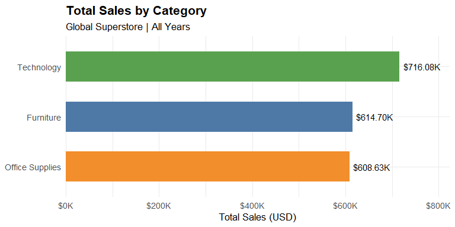

```r
chart1 <- df %>%
  group_by(Category) %>%
  summarise(Total_Sales = sum(Sales, na.rm = TRUE)) %>%
  ggplot(aes(x = reorder(Category, Total_Sales),
             y = Total_Sales,
             fill = Category)) +
  geom_col(show.legend = FALSE, width = 0.6) +
  geom_text(aes(label = dollar(Total_Sales, scale = 0.001, suffix = "K")),
            hjust = -0.1, size = 4) +
  coord_flip() +
  scale_y_continuous(
    labels = dollar_format(scale = 0.001, suffix = "K"),
    expand = expansion(mult = c(0, 0.15))
  ) +
  scale_fill_manual(values = c(
    "Furniture"       = "#4e79a7",
    "Office Supplies" = "#f28e2b",
    "Technology"      = "#59a14f"
  )) +
  labs(title    = "Total Sales by Category",
       subtitle = "Global Superstore | All Years",
       x = NULL, y = "Total Sales (USD)") +
  theme_minimal(base_size = 13) +
  theme(plot.title = element_text(face = "bold"))

print(chart1)
```

```r
ggsave("../reports/r_chart1_sales_category.png",
       chart1, width = 8, height = 4, dpi = 150)
cat("✅ Saved: r_chart1_sales_category.png\n")
```

```
✅ Saved: r_chart1_sales_category.png
```

## Chart 2: Profit Distribution by Region

A box plot is ideal here because it shows the **median**, **interquartile range**, and **outliers** for each region in one view — much more informative than a simple bar chart of averages. Key functions:

- **`geom_boxplot()`** — draws the box plot per group
- **`geom_hline(yintercept = 0)`** — adds a red dashed break-even line
- **`scale_fill_brewer()`** — applies a pre-built accessible color palette

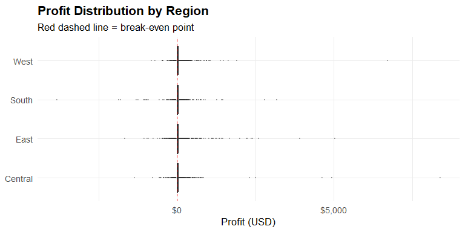

```r
chart2 <- df %>%
  filter(`Profit Margin %` > -100) %>%
  ggplot(aes(x = reorder(Region, Profit, median),
             y = Profit,
             fill = Region)) +
  geom_boxplot(outlier.size  = 0.5,
               outlier.alpha = 0.3,
               show.legend   = FALSE) +
  geom_hline(yintercept = 0, linetype = "dashed",
             color = "red", linewidth = 0.7) +
  coord_flip() +
  scale_y_continuous(labels = dollar_format()) +
  scale_fill_brewer(palette = "Set2") +
  labs(title    = "Profit Distribution by Region",
       subtitle = "Red dashed line = break-even point",
       x = NULL, y = "Profit (USD)") +
  theme_minimal(base_size = 13) +
  theme(plot.title = element_text(face = "bold"))

print(chart2)
```

```r
ggsave("../reports/r_chart2_profit_region.png",
       chart2, width = 8, height = 4, dpi = 150)
cat("✅ Saved: r_chart2_profit_region.png\n")
```

```
✅ Saved: r_chart2_profit_region.png
```

## Chart 3: Monthly Sales Trend

This chart tracks how total sales evolved over time and adds a smoothed trend line to remove noise. Key functions:

- **`floor_date()`** from lubridate — rounds dates down to month start, equivalent to `pd.Grouper(freq='M')` in pandas
- **`geom_line()`** — draws the actual monthly values
- **`geom_smooth(method = "loess")`** — adds a smoothed trend line with confidence band, equivalent to seaborn’s `regplot`

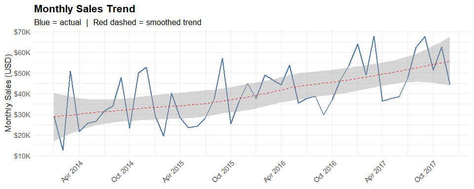

```r
chart3 <- df %>%
  mutate(YearMonth = floor_date(Order.Date, "month")) %>%
  group_by(YearMonth) %>%
  summarise(Monthly_Sales = sum(Sales, na.rm = TRUE)) %>%
  ggplot(aes(x = YearMonth, y = Monthly_Sales)) +
  geom_line(color = "#4e79a7", linewidth = 1) +
  geom_smooth(method   = "loess", se = TRUE,
              color    = "red",
              linetype = "dashed", linewidth = 0.7) +
  scale_x_date(date_breaks = "6 months",
               date_labels = "%b %Y") +
  scale_y_continuous(labels = dollar_format(scale = 0.001, suffix = "K")) +
  labs(title    = "Monthly Sales Trend",
       subtitle = "Blue = actual  |  Red dashed = smoothed trend",
       x = NULL, y = "Monthly Sales (USD)") +
  theme_minimal(base_size = 13) +
  theme(plot.title  = element_text(face = "bold"),
        axis.text.x = element_text(angle = 45, hjust = 1))

print(chart3)
```

```r
ggsave("../reports/r_chart3_monthly_trend.png",
       chart3, width = 10, height = 4, dpi = 150)
cat("✅ Saved: r_chart3_monthly_trend.png\n")
```

```
✅ Saved: r_chart3_monthly_trend.png
```

## Chunk 7 — Chart 4: Discount vs Profit Margin %

This scatter plot investigates whether higher discounts lead to lower profit margins — a critical business question. Key functions:

- **`geom_point(alpha = 0.3)`** — draws points with transparency to handle overplotting
- **`geom_smooth(method = "lm")`** — adds a linear regression line per category, equivalent to seaborn’s `lmplot`
- **`percent_format()`** — formats x-axis values as percentages e.g. 20%

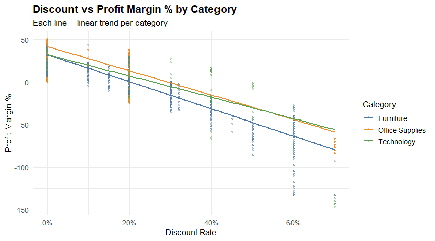

```r
chart4 <- df %>%
  filter(`Profit Margin %` > -150) %>%
  ggplot(aes(x     = Discount,
             y     = `Profit Margin %`,
             color = Category)) +
  geom_point(alpha = 0.3, size = 1) +
  geom_smooth(method = "lm", se = FALSE, linewidth = 1) +
  geom_hline(yintercept = 0, linetype = "dashed", color = "black") +
  scale_x_continuous(labels = percent_format()) +
  scale_color_manual(values = c(
    "Furniture"       = "#4e79a7",
    "Office Supplies" = "#f28e2b",
    "Technology"      = "#59a14f"
  )) +
  labs(title    = "Discount vs Profit Margin % by Category",
       subtitle = "Each line = linear trend per category",
       x        = "Discount Rate",
       y        = "Profit Margin %",
       color    = "Category") +
  theme_minimal(base_size = 13) +
  theme(plot.title = element_text(face = "bold"))

print(chart4)
```

```r
ggsave("../reports/r_chart4_discount_profit.png",
       chart4, width = 9, height = 5, dpi = 150)
cat("✅ Saved: r_chart4_discount_profit.png\n")
```

```
✅ Saved: r_chart4_discount_profit.png
```

## Chart 5: Sales by Region and Segment

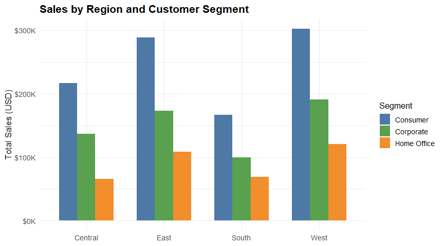

```r
chart5 <- df %>%
  group_by(Region, Segment) %>%
  summarise(Total_Sales = sum(Sales, na.rm = TRUE), .groups = "drop") %>%
  ggplot(aes(x = Region, y = Total_Sales, fill = Segment)) +
  geom_col(position = "dodge", width = 0.7) +
  scale_y_continuous(labels = dollar_format(scale = 0.001, suffix = "K")) +
  scale_fill_manual(values = c(
    "Consumer"    = "#4e79a7",
    "Corporate"   = "#59a14f",
    "Home Office" = "#f28e2b"
  )) +
  labs(title    = "Sales by Region and Customer Segment",
       x = NULL, y = "Total Sales (USD)", fill = "Segment") +
  theme_minimal(base_size = 13) +
  theme(plot.title = element_text(face = "bold"))

print(chart5)
```

```r
ggsave("../reports/r_chart5_segment_region.png",
       chart5, width = 9, height = 5, dpi = 150)
cat("✅ Saved: r_chart5_segment_region.png\n")
```

```
✅ Saved: r_chart5_segment_region.png
```

## Chart 6: Profit Tier Distribution

A donut chart shows the proportion of orders falling into each profit tier — a column engineered in Notebook 01. Key functions:

- **`count()`** — equivalent to `value_counts()` in pandas
- **`coord_polar(theta = "y")`** — converts bar chart into a pie/donut
- **`xlim(0.5, 2.5)`** — creates the donut hole by limiting x-axis range
- **`position_stack(vjust = 0.5)`** — centres labels inside each segment

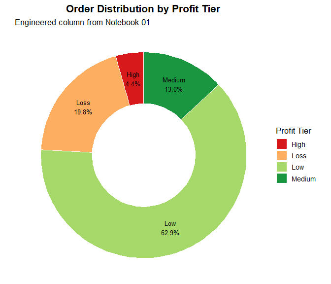

```r
tier_counts <- df %>%
  count(`Profit Tier`) %>%
  mutate(
    pct   = n / sum(n),
    label = paste0(`Profit Tier`, "\n", percent(pct, accuracy = 0.1))
  )

chart6 <- ggplot(tier_counts,
                 aes(x = 2, y = n, fill = `Profit Tier`)) +
  geom_col(width = 1, color = "white") +
  coord_polar(theta = "y") +
  xlim(0.5, 2.5) +
  geom_text(aes(label = label),
            position = position_stack(vjust = 0.5), size = 3.5) +
  scale_fill_brewer(palette = "RdYlGn") +
  labs(title    = "Order Distribution by Profit Tier",
       subtitle = "Engineered column from Notebook 01",
       fill     = "Profit Tier") +
  theme_void(base_size = 13) +
  theme(plot.title = element_text(face = "bold", hjust = 0.5))

print(chart6)
```

```r
ggsave("../reports/r_chart6_profit_tier.png",
       chart6, width = 7, height = 6, dpi = 150)
cat("✅ Saved: r_chart6_profit_tier.png\n")
```

```
✅ Saved: r_chart6_profit_tier.png
```

## Chunk 10 — Summary

All 6 charts have been generated and saved to the `../reports/` directory using `ggsave()`. Each chart was built using **ggplot2’s layered grammar of graphics** — where you start with data, map variables to aesthetics (`aes()`), then add geometric layers (`geom_*()`) one at a time.

| Chart | File | Insight |
| --- | --- | --- |
| Sales by Category | r_chart1_sales_category.png | Technology leads in revenue |
| Profit by Region | r_chart2_profit_region.png | Regional profit spread and outliers |
| Monthly Trend | r_chart3_monthly_trend.png | Seasonal sales patterns |
| Discount vs Profit | r_chart4_discount_profit.png | Discount impact on margins |
| Region x Segment | r_chart5_segment_region.png | Segment performance by region |
| Profit Tier | r_chart6_profit_tier.png | Order profitability distribution |

```r
cat("========================================\n")
cat("  Notebook 07 — R EDA Complete\n")
```

```
  Notebook 07 — R EDA Complete
```

```r
cat("========================================\n")
cat("→ Next: app.R — Shiny Dashboard\n")
```

```
→ Next: app.R — Shiny Dashboard
```